# Weather and Corn Yield Regressions

### Question 1b: Fit a quadratic time trend (i.e., year + year<sup>2</sup>) and make a plot. Is there evidence for slowing yield growth?

#### **Quadratic time trend analysis within Winneshiek County, Iowa**

#### *Quadratic Regression - Yield by Covariates: Year,Year<sup>2</sup>*

```r
# Create column for year^2

winne_yields$yearsq <- winne_yields$year^2

#Fit quadratic time trend with yield(y) and year and year^2 as covariates(x)

quad_timeLM <- lm(yield~year + yearsq, data = winne_yields)
summary(quad_timeLM)
```

```
##
## Call:
## lm(formula = yield ~ year + yearsq, data = winne_yields)
##
## Residuals:
##     Min      1Q  Median      3Q     Max
## -51.384  -3.115   1.388   9.743  25.324
##
## Coefficients:
##               Estimate Std. Error t value Pr(>|t|)
## (Intercept)  2.583e+04  8.580e+04   0.301    0.765
## year        -2.812e+01  8.576e+01  -0.328    0.745
## yearsq       7.641e-03  2.143e-02   0.357    0.723
##
## Residual standard error: 17.17 on 38 degrees of freedom
## Multiple R-squared:  0.7559, Adjusted R-squared:  0.7431
## F-statistic: 58.84 on 2 and 38 DF,  p-value: 2.311e-12
```

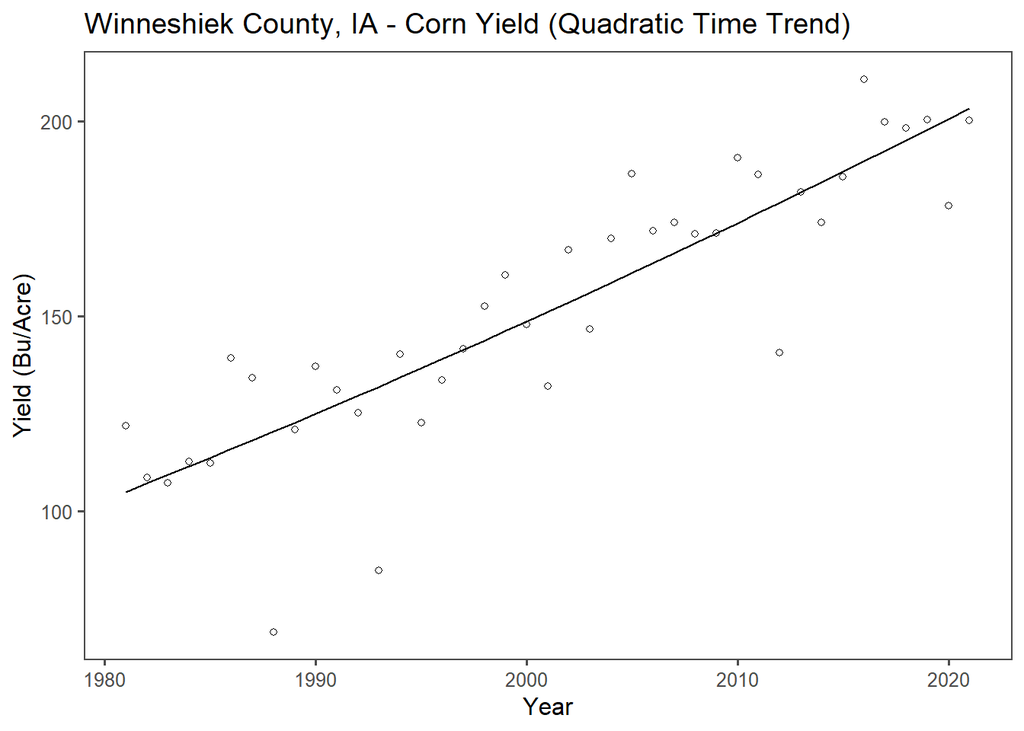

```r
#Add fitted values from the quad model to data frame

winne_yields$fitted_q <- quad_timeLM$fitted.values

#Plot yield(y) by year (x)
#Add line for quadratic time trend

ggplot(winne_yields) +
  geom_point(mapping = aes(x = year, y = yield), shape = 1) +
  geom_line(mapping = aes(x = year, y = fitted_q)) +
  theme_few() +
  labs(x = expression("Year"), y = "Yield (Bu/Acre)", title = "Winneshiek County, IA - Corn Yield (Quadratic Time Trend)")
```

There is not strong evidence to suggest there is slowing yield growth over time. The p-value associated with the overall quadratic regression on year and year<sup>2</sup> is 2.311e-12 and less than $\alpha$ = 0.5, suggesting there is a relationship between yield and one of the covariates in the model. However, the p-value(s) for each variable independently, year (p-value = 0.745) and year<sup>2</sup> (p-value = 0.723), are greater than $\alpha$ = 0.5. Given the results of the regression on year alone suggest a linear relationship between yield and year, the linear year term is likely contributing to overall model significance. Thus, this implies the quadratic year<sup>2</sup> term is not applicable.

Furthermore, the R-squared values between the linear model and quadratic model with regressor(s) year and/or year<sup>2</sup> are comparable at 75.51% or 75.59%, respectively. However, with reference to the adjusted R-squared value, 74.31% of the variation in yield is explained by the quadratic regression on year (and year<sup>2</sup>); this is slightly less the variation in yield explained by the regression on year alone (75.51%). These pieces of information suggest the higher order model, with adding in year<sup>2</sup>, does not provide greater predictive ability.

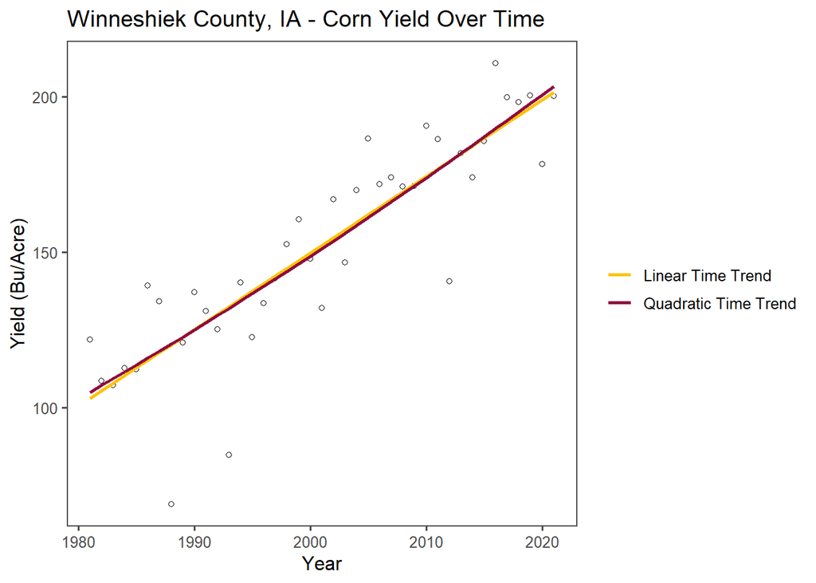

```r
#Plot time trend lines combined

ggplot(winne_yields) +
  geom_point(mapping = aes(x = year, y = yield), shape = 1) +
  geom_line(mapping = aes(x = year, y = fitted_l, col="Linear Time Trend"), size=1) +
  geom_line(mapping = aes(x = year, y = fitted_q, col="Quadratic Time Trend"),size=1) +
  theme_few() +
  labs(colour = NULL) +
  scale_color_manual(values=c("#FFC300","#900C3F"))+
  labs(x = expression("Year"), y = "Yield (Bu/Acre)", title = "Winneshiek County, IA - Corn Yield Over Time")
```

### Question 2 – Time Series: Let’s analyze the relationship between temperature and yields for the Winneshiek County time series. Use data on yield and summer avg Tmax. Is adding year or Tmax<sup>2</sup> to your model helpful? Make a plot and interpret the results.

#### **Time series analysis within Winneshiek County, Iowa**

#### *SLR - Yield by Covariate: Average Summer Maximum Temperature*

```r
#Add average summer Tmax to winne_yield data

winne_summer_yield <- left_join(winne_yields,winnesummer, by = "year")%>%
  filter(!is.na(meantmax))

#Fit a model for yield(y) and average summer maximum temperature(x) alone

winne_tempLM <- lm(yield~meantmax, data=winne_summer_yield)
summary(winne_tempLM)
```

```
##
## Call:
## lm(formula = yield ~ meantmax, data = winne_summer_yield)
##
## Residuals:
##    Min     1Q Median     3Q    Max
## -71.96 -19.85  -3.19  24.64  61.72
##
## Coefficients:
##             Estimate Std. Error t value Pr(>|t|)
## (Intercept)  275.876    118.335   2.331   0.0255 *
## meantmax      -4.763      4.438  -1.073   0.2902
## ---
## Signif. codes:  0 '***' 0.001 '**' 0.01 '*' 0.05 '.' 0.1 ' ' 1
##
## Residual standard error: 32.88 on 36 degrees of freedom
## Multiple R-squared:  0.03101,    Adjusted R-squared:  0.004098
## F-statistic: 1.152 on 1 and 36 DF,  p-value: 0.2902
```

```r
#Add fitted values to data frame

winne_summer_yield$fitted_2 <- winne_tempLM$fitted.values
```

With a p-value of 0.2902 and greater than $\alpha$ = 0.05, we fail to reject the null hypothesis $H_0:\beta_1$ = 0. We do not have sufficient evidence to suggest there is a linear relationship between average summer maximum temperature and yield. 3.1% of the variation in corn yield is explained by the regression on average summer maximum temperature alone.

#### *Multiple Regression - Yield by Covariates: Average Summer Maximum Temperature, Year*

```r
#Add summer Tmax^2 to winne_summer_yield

winne_summer_yield$meantmaxsq <- winne_summer_yield$meantmax^2

#Fit a model for yield(y) with covariates(x): average summer max temp and year

temp_yearLM <- lm(yield~meantmax + year, data=winne_summer_yield)
summary(temp_yearLM)
```

```
##
## Call:
## lm(formula = yield ~ meantmax + year, data = winne_summer_yield)
##
## Residuals:
##     Min      1Q  Median      3Q     Max
## -53.071  -7.269   2.271   9.935  27.505
##
## Coefficients:
##              Estimate Std. Error t value Pr(>|t|)
## (Intercept) -4791.774    513.812  -9.326 5.10e-11 ***
## meantmax       -3.201      2.308  -1.387    0.174
## year            2.514      0.253   9.934 1.01e-11 ***
## ---
## Signif. codes:  0 '***' 0.001 '**' 0.01 '*' 0.05 '.' 0.1 ' ' 1
##
## Residual standard error: 17.06 on 35 degrees of freedom
## Multiple R-squared:  0.7463, Adjusted R-squared:  0.7318
## F-statistic: 51.48 on 2 and 35 DF,  p-value: 3.761e-11
```

```r
#Add fitted values from model to data frame

winne_summer_yield$fitted_2a <- temp_yearLM$fitted.values
```

#### *Quadratic Regression - Yield by Covariates: Average Summer Max Temperature, Max Temperature<sup>2</sup>*

```r
#Fit a model for yield with covariates: average summer max temp and max temp^2

quad_tempLM <- lm(yield~meantmax + meantmaxsq, data=winne_summer_yield)
summary(quad_tempLM)
```

```
##
## Call:
## lm(formula = yield ~ meantmax + meantmaxsq, data = winne_summer_yield)
##
## Residuals:
##     Min      1Q  Median      3Q     Max
## -56.587 -22.262  -0.982  22.409  52.798
##
## Coefficients:
##              Estimate Std. Error t value Pr(>|t|)
## (Intercept) -4223.604   1446.639  -2.920  0.00609 **
## meantmax      328.918    107.068   3.072  0.00410 **
## meantmaxsq     -6.173      1.979  -3.119  0.00362 **
## ---
## Signif. codes:  0 '***' 0.001 '**' 0.01 '*' 0.05 '.' 0.1 ' ' 1
##
## Residual standard error: 29.5 on 35 degrees of freedom
## Multiple R-squared:  0.2417, Adjusted R-squared:  0.1984
## F-statistic: 5.579 on 2 and 35 DF,  p-value: 0.007887
```

```r
#Add fitted values from model to data frame

winne_summer_yield$fitted_2b <- quad_tempLM$fitted.values
```

In prior analyses, we found there was not sufficient evidence of a linear relationship between yield and average summer max temp (p-value = 0.2902, R<sup>2</sup> = 3.1%). However, in adding the quadratic term to the model (Tmax<sup>2</sup>), 19.84% (Adjusted R-squared) of the variation in corn yield is explained by the regression on average summer max temp and average summer max temp squared. The quadratic model, therefore, describes greater variability in yield above and beyond the regression on average summer max temp alone. Furthermore, the p-value from the F-statistic for the quadratic model overall is 0.007887 and less than $\alpha$ = 0.05, whereas the p-value from the linear model F-statistic is 0.2902. This suggests the higher order model serves as a better predictive model.

When looking at the plot of yield by average summer maximum temperature, we can see there is high variability. However, the curvature of the line for the fitted quadratic model suggests corn yield increases with temperature until reaching an optimal temperature for plant growth, then declines with temperatures exceeding the optimal temperature.

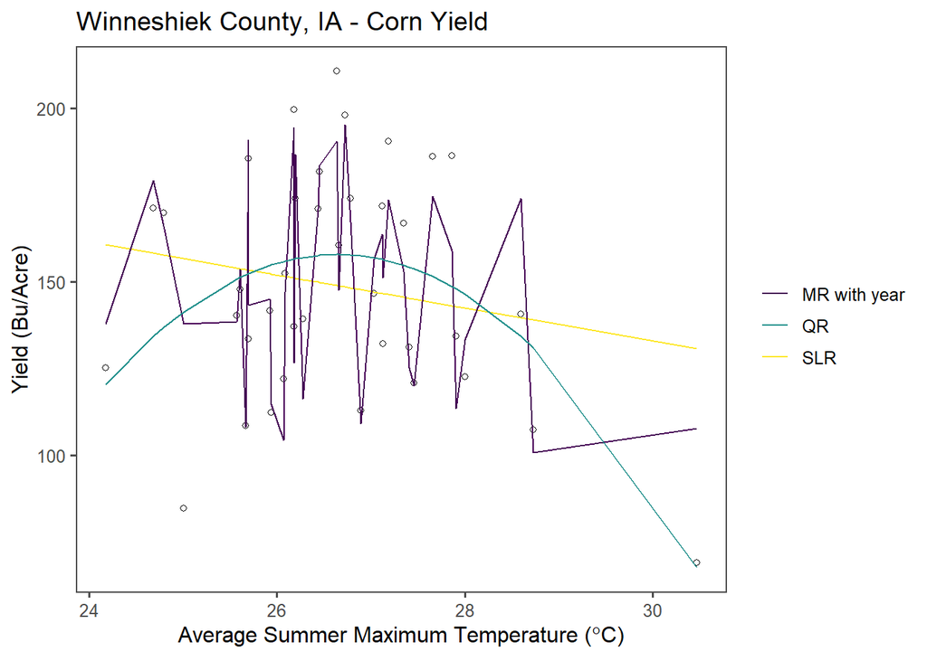

```r
#Plot corn yield (y) by Average Summer Maximum Temperature(x) with fitted values from regressions

ggplot(winne_summer_yield) +
  geom_point(mapping = aes(x = meantmax, y = yield), shape = 1) +
  geom_line(mapping = aes(x = meantmax, y = fitted_2, col="SLR")) +
  geom_line(mapping = aes(x = meantmax, y = fitted_2a, col="MR with year")) +
  geom_line(mapping = aes(x = meantmax, y = fitted_2b, col="QR")) +
  labs(colour = NULL) +
  theme_few() +
  scale_color_viridis(discrete=TRUE)+
  labs(x = expression("Average Summer Maximum Temperature ("*degree*C*")"), y = "Yield (Bu/Acre)", title = "Winneshiek County, IA - Corn Yield")
```

### Question 3 – Cross-Section: Analyze the relationship between temperature and yield across all counties in 2018. Is there a relationship? Interpret the results.

#### **Cross-section analysis across all Iowa Counties in 2018**

```r
#Rename county_ansi to countyfp

corn_yields <- cornyields %>%
  rename('countyfp'= county_ansi)

#Save countyfp as factor

corn_yields$countyfp <- as.factor(corn_yields$countyfp)

#Filter for 2018 yields only

county2018_yields <- corn_yields %>%
  filter(year==2018)

#Add average summer maximum temp for 2018

tmax2018 <- tmaxdf %>%
  filter(year==2018)%>%
  group_by(countyfp) %>%
  filter(doy >= 152 & doy <= 243) %>%
  summarize(meantmax = mean(tmax))

#Combine average summer max temperature with county yield data for 2018

countytmax2018 <- inner_join(county2018_yields, tmax2018, by='countyfp')
```

#### *SLR - Yield by Covariate: Average Summer Max Temperature*

```r
#Fit a linear model with yield (y) and average summer Tmax (x)

yield_2018LM <- lm(yield~meantmax, data=countytmax2018)
summary(yield_2018LM)
```

```
##
## Call:
## lm(formula = yield ~ meantmax, data = countytmax2018)
##
## Residuals:
##     Min      1Q  Median      3Q     Max
## -42.983 -15.041   0.955  16.795  31.999
##
## Coefficients:
##             Estimate Std. Error t value Pr(>|t|)
## (Intercept)  312.466     63.387   4.929 3.69e-06 ***
## meantmax      -4.216      2.241  -1.882   0.0631 .
## ---
## Signif. codes:  0 '***' 0.001 '**' 0.01 '*' 0.05 '.' 0.1 ' ' 1
##
## Residual standard error: 19.64 on 91 degrees of freedom
## Multiple R-squared:  0.03745,    Adjusted R-squared:  0.02687
## F-statistic: 3.541 on 1 and 91 DF,  p-value: 0.06308
```

```r
#Add fitted values from model to data frame

countytmax2018$fitted_l <-yield_2018LM$fitted.values

#Plot yield(y) by average summer maximum temperature (x)

# ggplot(aes(x = meantmax, y = yield), data = countytmax2018) +
#   geom_point(shape = 1) +
#   geom_line(mapping = aes(x=meantmax, y=fitted_l))+
#   theme_few() +
#   labs(x = expression("Average Summer Maximum Temperature ("*degree*C*")"), y = "Yield (Bu/Acre)", title = "Corn Yields across Iowa Counties in 2018")
```

2.7% of the variation in corn yields is explained by a simple linear regression on average summer max temp across all Iowa counties in 2018. With a p-value of 0.0631 and greater than $\alpha$ = 0.05, we fail to reject the null hypothesis $H_0:\beta_1$ = 0. We do not have sufficient evidence to suggest there is a linear relationship between yield and average summer max temp across all Iowa counties in 2018.

#### *QR - Yield by Covariates: Average Summer Max Temperature, Max Temperature<sup>2</sup>*

```r
#Add Tmax^2 to data frame

countytmax2018$meantmaxsq <- countytmax2018$meantmax^2

#Fit a quadratic model with yield (y) and average summer Tmax and Tmax^2

yield_2018_QR<- lm(yield~meantmax + meantmaxsq, data=countytmax2018)
summary(yield_2018_QR)
```

```
##
## Call:
## lm(formula = yield ~ meantmax + meantmaxsq, data = countytmax2018)
##
## Residuals:
##     Min      1Q  Median      3Q     Max
## -44.221 -15.399   5.007  14.541  30.879
##
## Coefficients:
##              Estimate Std. Error t value Pr(>|t|)
## (Intercept) -5501.602   1860.830  -2.957  0.00397 **
## meantmax      406.789    131.493   3.094  0.00263 **
## meantmaxsq     -7.256      2.321  -3.126  0.00239 **
## ---
## Signif. codes:  0 '***' 0.001 '**' 0.01 '*' 0.05 '.' 0.1 ' ' 1
##
## Residual standard error: 18.75 on 90 degrees of freedom
## Multiple R-squared:  0.1317, Adjusted R-squared:  0.1124
## F-statistic: 6.827 on 2 and 90 DF,  p-value: 0.001736
```

```r
#Add fitted values from model to data frame

countytmax2018$fitted_q <-yield_2018_QR$fitted.values

#Plot yield(y) by average summer maximum temperature (x)

# ggplot(aes(x = meantmax, y = yield), data = countytmax2018) +
#   geom_point(shape = 1) +
#   geom_line(mapping = aes(x=meantmax, y=fitted_q))+
#   theme_few() +
#   labs(x = expression("Average Summer Maximum Temperature ("*degree*C*")"), y = "Yield (Bu/Acre)", title = "Corn Yields across Iowa Counties in 2018")
```

While we did not find enough evidence of a linear relationship between average summer max temp and yield across all Iowa counties in 2018 (p-value 0.0631 > $\alpha$), there is evidence of an overall significant quadratic temperature trend (p-value = 0.001736). 11.24% of the variation in corn yield is explained by the quadratic regression on mean max temperature and mean max temperature squared, across all Iowa counties in 2018.

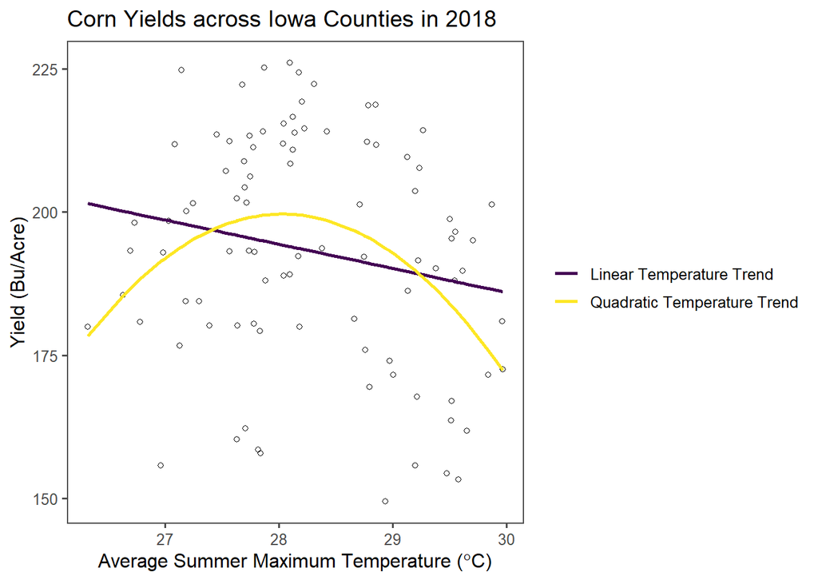

```r
#Combined plot of linear and quadratic temperature models

ggplot(aes(x = meantmax, y = yield), data = countytmax2018) +
  geom_point(shape = 1) +
  geom_line(mapping = aes(x=meantmax, y=fitted_l, col="Linear Temperature Trend"), size=1)+
  geom_line(mapping = aes(x=meantmax, y=fitted_q, col="Quadratic Temperature Trend"), size=1)+
  labs(colour = NULL) +
  theme_few() +
  scale_color_viridis(discrete=TRUE)+
  labs(x = expression("Average Summer Maximum Temperature ("*degree*C*")"), y = "Yield (Bu/Acre)", title = "Corn Yields across Iowa Counties in 2018")
```

### Question 4 – Panel: One way to leverage multiple time series is to group all data into what is called a “panel” regression. Convert the county ID code (“countyfp” or “county_ansi”) into factor using as.factor, then include this variable in a regression using all counties’ yield and summer temperature data. How does the significance of your temperature coefficients (Tmax, Tmax<sup>2</sup>) change? Make a plot comparing actual and fitted yields and interpret the results of your model.

```r
#Combine county and temperature data

yearly_co_temp <- tmaxdf %>%
  group_by(countyfp,year)%>%
  filter(doy >= 152 & doy <= 243) %>%
  summarize(meantmax = mean(tmax))
co_yearly_join <- left_join(yearly_co_temp, corn_yields, by= c('countyfp','year'))%>%
  filter(!is.na(yield))

#Add Tmax^2 to data frame

co_yearly_join$meantmaxsq <- co_yearly_join$meantmax^2
```

#### *SLR - Yield by Covariate: Year*

```r
SLR_LM <- lm(yield~ year, data = co_yearly_join)
summary(SLR_LM)
```

```
##
## Call:
## lm(formula = yield ~ year, data = co_yearly_join)
##
## Residuals:
##     Min      1Q  Median      3Q     Max
## -128.90  -10.56    4.87   16.68   45.17
##
## Coefficients:
##               Estimate Std. Error t value Pr(>|t|)
## (Intercept) -4.508e+03  7.244e+01  -62.23   <2e-16 ***
## year         2.327e+00  3.623e-02   64.22   <2e-16 ***
## ---
## Signif. codes:  0 '***' 0.001 '**' 0.01 '*' 0.05 '.' 0.1 ' ' 1
##
## Residual standard error: 24.25 on 3746 degrees of freedom
## Multiple R-squared:  0.5241, Adjusted R-squared:  0.5239
## F-statistic:  4125 on 1 and 3746 DF,  p-value: < 2.2e-16
```

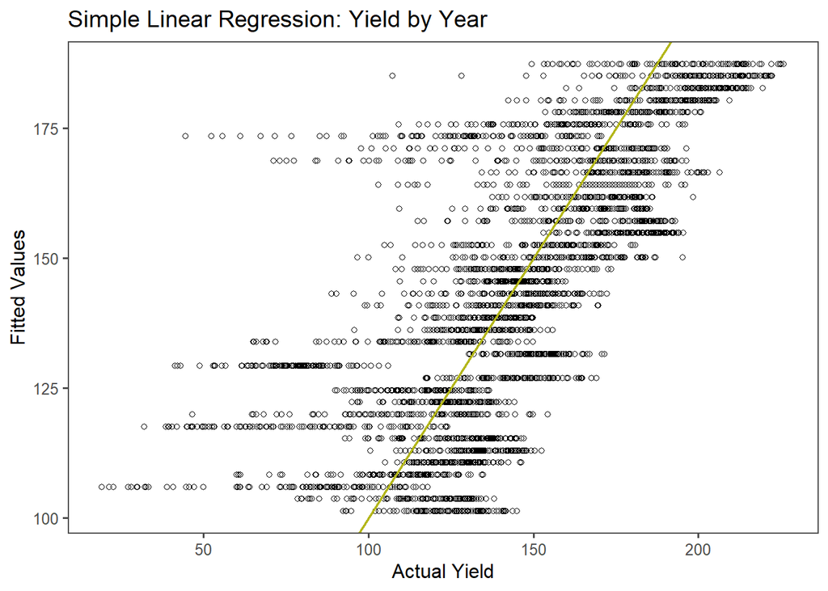

```r
co_yearly_join$fit_SLR <- SLR_LM$fitted.values

# Plot actual versus fitted yields

ggplot(co_yearly_join) +
  geom_point(mapping = aes(x = yield, y = fit_SLR), shape = 1) +
  geom_abline(color="#B3B61A", size=0.75)+
  theme_few() +
  labs(x = "Actual Yield", y = "Fitted Values", title="Simple Linear Regression: Yield by Year")
```

#### *Quadratic Regression - Yield by Covariates: Average Summer Maximum Temperature, Max Temperature<sup>2</sup>*

```r
QR_LM <- lm(yield~ meantmax+ meantmaxsq, data = co_yearly_join)
summary(QR_LM)
```

```
##
## Call:
## lm(formula = yield ~ meantmax + meantmaxsq, data = co_yearly_join)
##
## Residuals:
##      Min       1Q   Median       3Q      Max
## -113.151  -21.982   -2.794   24.860   82.006
##
## Coefficients:
##               Estimate Std. Error t value Pr(>|t|)
## (Intercept) -2098.6219   139.4315  -15.05   <2e-16 ***
## meantmax      168.9590     9.9402   17.00   <2e-16 ***
## meantmaxsq     -3.1665     0.1769  -17.90   <2e-16 ***
## ---
## Signif. codes:  0 '***' 0.001 '**' 0.01 '*' 0.05 '.' 0.1 ' ' 1
##
## Residual standard error: 31.55 on 3745 degrees of freedom
## Multiple R-squared:  0.1947, Adjusted R-squared:  0.1943
## F-statistic: 452.8 on 2 and 3745 DF,  p-value: < 2.2e-16
```

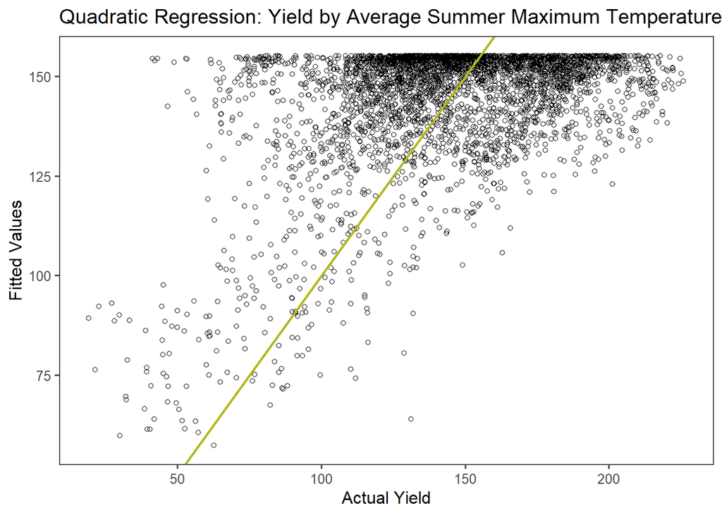

```r
co_yearly_join$fit_QR <- QR_LM$fitted.values

# Plot actual versus fitted yields

ggplot(co_yearly_join) +
  geom_point(mapping = aes(x = yield, y = fit_QR), shape = 1) +
   geom_abline(color="#B3B61A", size=0.75)+
  theme_few() +
  labs(x = "Actual Yield", y = "Fitted Values", title="Quadratic Regression: Yield by Average Summer Maximum Temperature")
```

#### *Multiple Regression - Yield by Covariates: Average Summer Maximum Temperature, Max Temperature<sup>2</sup>, Year*

```r
# Fit multiple regression yield by Average Summer Maximum Temperature, Max Temperature^2, Year

MR_LM <- lm(yield~ meantmax+ meantmaxsq+ year, data = co_yearly_join)
summary(MR_LM)
```

```
##
## Call:
## lm(formula = yield ~ meantmax + meantmaxsq + year, data = co_yearly_join)
##
## Residuals:
##     Min      1Q  Median      3Q     Max
## -97.177  -9.793   2.456  13.908  48.915
##
## Coefficients:
##               Estimate Std. Error t value Pr(>|t|)
## (Intercept) -5.829e+03  1.051e+02  -55.45   <2e-16 ***
## meantmax     1.199e+02  6.527e+00   18.38   <2e-16 ***
## meantmaxsq  -2.275e+00  1.162e-01  -19.58   <2e-16 ***
## year         2.202e+00  3.101e-02   71.00   <2e-16 ***
## ---
## Signif. codes:  0 '***' 0.001 '**' 0.01 '*' 0.05 '.' 0.1 ' ' 1
##
## Residual standard error: 20.6 on 3744 degrees of freedom
## Multiple R-squared:  0.6568, Adjusted R-squared:  0.6565
## F-statistic:  2389 on 3 and 3744 DF,  p-value: < 2.2e-16
```

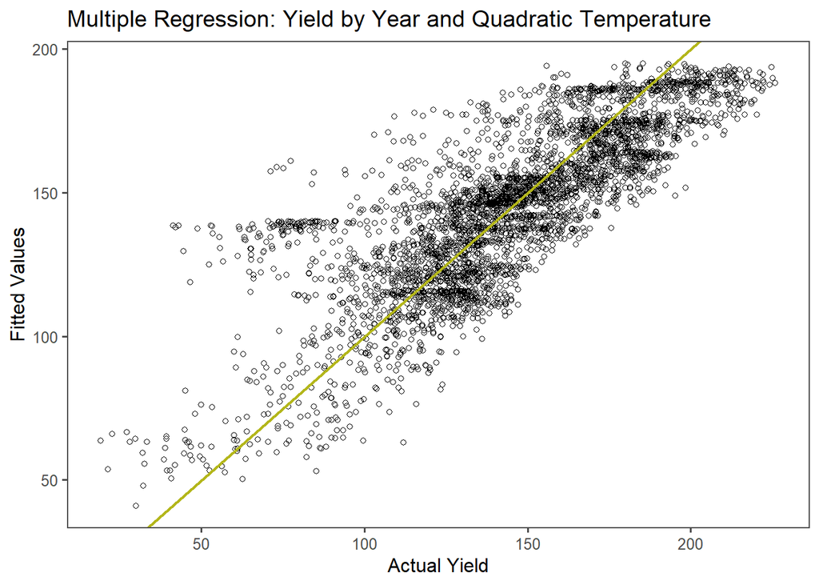

```r
co_yearly_join$fit_MR <- MR_LM$fitted.values

# Plot actual versus fitted yields

ggplot(co_yearly_join) +
  geom_point(mapping = aes(x = yield, y = fit_MR), shape = 1) +
  geom_abline(color="#B3B61A", size=0.75)+
  theme_few() +
  labs(x = "Actual Yield", y = "Fitted Values", title="Multiple Regression: Yield by Year and Quadratic Temperature")
```

#### *Panel Regression - Yield by Covariates: Average Summer Maximum Temperature, Max Temperature<sup>2</sup>, Year, County code*

```r
#Fit a panel regression

panelLM <- lm(yield~ meantmax+ meantmaxsq+ year+countyfp, data = co_yearly_join)
summary(panelLM)
```

```
##
## Call:
## lm(formula = yield ~ meantmax + meantmaxsq + year + countyfp,
##     data = co_yearly_join)
##
## Residuals:
##     Min      1Q  Median      3Q     Max
## -81.645  -9.720   1.924  13.232  40.409
##
## Coefficients:
##               Estimate Std. Error t value Pr(>|t|)
## (Intercept) -5.815e+03  9.802e+01 -59.319  < 2e-16 ***
## meantmax     1.182e+02  6.108e+00  19.352  < 2e-16 ***
## meantmaxsq  -2.225e+00  1.085e-01 -20.503  < 2e-16 ***
## year         2.203e+00  2.836e-02  77.664  < 2e-16 ***
## countyfp147 -4.601e+00  4.322e+00  -1.065 0.287100
## countyfp13  -4.573e+00  4.322e+00  -1.058 0.290041
## countyfp99   2.537e+00  4.322e+00   0.587 0.557264
## countyfp195 -5.740e+00  4.339e+00  -1.323 0.186000
## countyfp67  -7.072e+00  4.324e+00  -1.636 0.102029
## countyfp107 -9.660e+00  4.325e+00  -2.233 0.025596 *
## countyfp15   3.120e+00  4.322e+00   0.722 0.470379
## countyfp57  -1.366e+00  4.327e+00  -0.316 0.752212
## countyfp127  2.318e+00  4.321e+00   0.536 0.591719
## countyfp123 -3.711e+00  4.325e+00  -0.858 0.390951
## countyfp81  -3.157e+00  4.327e+00  -0.729 0.465744
## countyfp129 -1.637e+00  4.396e+00  -0.372 0.709703
## countyfp1   -1.186e+01  4.325e+00  -2.743 0.006124 **
## countyfp175 -2.341e+01  4.354e+00  -5.377 8.03e-08 ***
## countyfp19  -4.212e+00  4.324e+00  -0.974 0.330092
## countyfp37  -9.693e+00  4.328e+00  -2.240 0.025182 *
## countyfp109  3.589e-01  4.324e+00   0.083 0.933863
## countyfp165 -4.189e+00  4.322e+00  -0.969 0.332408
## countyfp51  -2.644e+01  4.360e+00  -6.063 1.47e-09 ***
## countyfp69  -5.518e-01  4.322e+00  -0.128 0.898414
## countyfp137 -5.977e+00  4.330e+00  -1.381 0.167514
## countyfp9   -6.795e+00  4.322e+00  -1.572 0.115958
## countyfp87  -6.583e+00  4.328e+00  -1.521 0.128366
## countyfp5   -9.147e+00  4.329e+00  -2.113 0.034697 *
## countyfp189 -3.627e+00  4.330e+00  -0.838 0.402306
```

[output cut: 64 more lines]

```
## countyfp183 -1.446e+00  4.328e+00  -0.334 0.738278
## countyfp33  -7.281e+00  4.326e+00  -1.683 0.092484 .
## countyfp43  -2.998e+00  4.326e+00  -0.693 0.488271
## countyfp73   2.754e+00  4.323e+00   0.637 0.524176
## countyfp161 -2.473e+00  4.321e+00  -0.572 0.567164
## countyfp103 -7.483e+00  4.322e+00  -1.731 0.083476 .
## countyfp119 -2.534e+00  4.321e+00  -0.586 0.557604
## countyfp163  4.415e+00  4.321e+00   1.022 0.306959
## countyfp171 -2.122e+00  4.321e+00  -0.491 0.623334
## ---
## Signif. codes:  0 '***' 0.001 '**' 0.01 '*' 0.05 '.' 0.1 ' ' 1
##
## Residual standard error: 18.83 on 3646 degrees of freedom
## Multiple R-squared:  0.7207, Adjusted R-squared:  0.7129
## F-statistic: 93.13 on 101 and 3646 DF,  p-value: < 2.2e-16
```

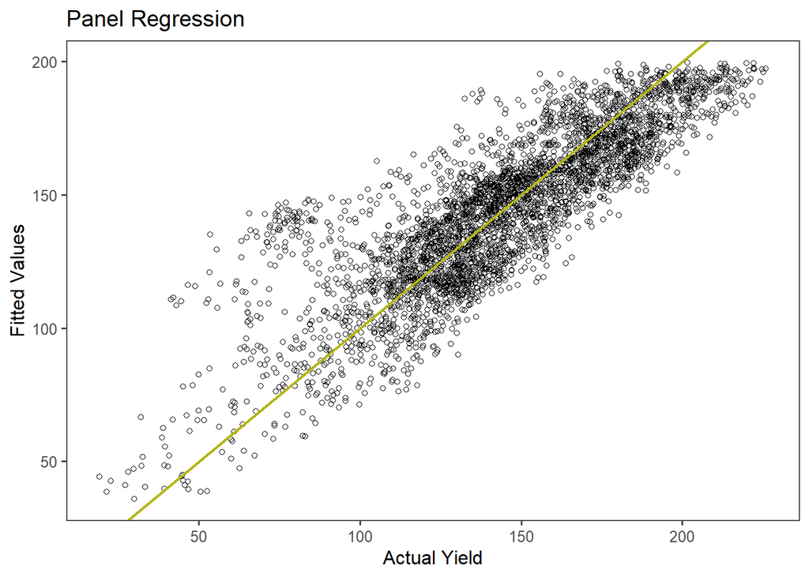

```r
co_yearly_join$fit_panel <- panelLM$fitted.values

# Plot actual versus fitted yields

ggplot(co_yearly_join) +
  geom_point(mapping = aes(x = yield, y = fit_panel), shape = 1) +
  geom_abline(color="#B3B61A", size=0.75)+
  theme_few()+
  labs(x = "Actual Yield", y = "Fitted Values", title="Panel Regression")
```

In order to assess the applicability of the panel regression model (later referred to as model D), I ran the following models for comparison: a) a simple linear regression with yield by year, b) a quadratic regression with yield by average summer max temp and average summer max temp<sup>2</sup>, and c) a multiple regression with yield by year, average summer max temp, and max temp<sup>2</sup>. For model A, 52.41% of the variability in corn yield is explained by the regression on year. For model B, 19.43% (adjusted R<sup>2</sup>) of the variation in corn yield is explained by the quadratic regression on average summer max temperature. For model C, 65.65% (adjusted R<sup>2</sup>) of the variation in yield is explained by the regression on the model covariates. Finally, for model D, 71.29% (adjusted R<sup>2</sup>) of the variation in corn yield is explained by all covariates in the model including county code.

The following list includes the p-values associated with the coefficients for average summer max temperature and average summer max temp<sup>2</sup>, while holding all else constant, in the models:

Model B: Average Max Temp (p-value = <2e-16), Max Temp<sup>2</sup> (p-value = <2e-16)

Model C: Average Max Temp (p-value = <2e-16), Max Temp<sup>2</sup> (p-value = <2e-16)

Model D: Average Max Temp (p-value = <2e-16), Max Temp<sup>2</sup> (p-value = <2e-16)

As evidenced by the information above, the significance of the temperature coefficients remained consistent across models. In the case of the panel regression, when incorporating county ID into the model, it could be that the coefficients for temperature remained consistent given counties within Iowa may experience broadly similar weather (and thus temperature regimes).

### Question 5 – Soybeans: Download NASS data on soybean yields and explore either a time series relationship for a given county, the cross-sectional relationship for a given year, or a panel across all counties and years.

#### **Cross-section analysis of soy yields across all Iowa Counties in 2018**

```r
#Rename county_ansi to countyfp

soy_yields <- soyyields %>%
  rename('countyfp'= county_ansi)

#Save countyfp as factor

soy_yields$countyfp <- as.factor(soy_yields$countyfp)

#Filter for 2018 yields only

county2018_soy <- soy_yields %>%
  filter(year==2018)

#Combine average summer max temperature with county yield data for 2018

soytmax2018 <- inner_join(county2018_soy, tmax2018, by='countyfp')
```

#### *SLR - Soy Yield by Covariate: Average Summer Max Temperature*

```r
#Fit a linear model with soy yield (y) and average summer Tmax (x)

soy_2018LM <- lm(yield~meantmax, data=soytmax2018)
summary(soy_2018LM)
```

```
##
## Call:
## lm(formula = yield ~ meantmax, data = soytmax2018)
##
## Residuals:
##      Min       1Q   Median       3Q      Max
## -13.2465  -3.9132  -0.0974   4.3063  10.1384
##
## Coefficients:
##             Estimate Std. Error t value Pr(>|t|)
## (Intercept)  76.5642    15.7866   4.850 4.88e-06 ***
## meantmax     -0.7365     0.5570  -1.322    0.189
## ---
## Signif. codes:  0 '***' 0.001 '**' 0.01 '*' 0.05 '.' 0.1 ' ' 1
##
## Residual standard error: 5.146 on 94 degrees of freedom
## Multiple R-squared:  0.01826,    Adjusted R-squared:  0.007819
## F-statistic: 1.749 on 1 and 94 DF,  p-value: 0.1893
```

```r
#Add fitted values from model to data frame

soytmax2018$fitted_l <-soy_2018LM$fitted.values
```

With a p-value of 0.189 and greater than $\alpha$ = 0.05, we fail to reject the null hypothesis $H_0:\beta_1$ = 0. We do not have sufficient evidence to suggest there is a linear relationship between soy yield and average summer max temp across all Iowa counties in 2018. 0.78% of the variation in soy yields is explained by a simple linear regression on average summer max temp across all Iowa counties in 2018.

#### *QR - Soy Yield by Covariates: Average Summer Max Temperature, Max Temperature<sup>2</sup>*

```r
#Add Tmax^2 to data frame

soytmax2018$meantmaxsq <- soytmax2018$meantmax^2

#Fit a quadratic model with soy yield (y) and average summer Tmax and Tmax^2

soy_2018_QR<- lm(yield~meantmax + meantmaxsq, data=soytmax2018)
summary(soy_2018_QR)
```

```
##
## Call:
## lm(formula = yield ~ meantmax + meantmaxsq, data = soytmax2018)
##
## Residuals:
##      Min       1Q   Median       3Q      Max
## -12.0464  -3.7212   0.3655   3.5239  12.6002
##
## Coefficients:
##               Estimate Std. Error t value Pr(>|t|)
## (Intercept) -1401.3584   453.0686  -3.093  0.00262 **
## meantmax      103.5349    31.9520   3.240  0.00166 **
## meantmaxsq     -1.8371     0.5629  -3.264  0.00154 **
## ---
## Signif. codes:  0 '***' 0.001 '**' 0.01 '*' 0.05 '.' 0.1 ' ' 1
##
## Residual standard error: 4.9 on 93 degrees of freedom
## Multiple R-squared:  0.1192, Adjusted R-squared:  0.1002
## F-statistic:  6.29 on 2 and 93 DF,  p-value: 0.00274
```

```r
#Add fitted values from model to data frame

soytmax2018$fitted_q <-soy_2018_QR$fitted.values
```

Similar to as observed with corn yields, soy yields in response to average summer max temp are better predicted by a quadratic regression. The p-value from the F-statistic for the linear model is 0.1893 and greater than $\alpha$ = 0.5, while the p-value for the overall quadratic model F-statistic is 0.00274 < $\alpha$. 10.02% (Adjusted R<sup>2</sup>) of the variation in soy yield is explained by the quadratic regression on mean max temperature and mean max temperature<sup>2</sup>, across all Iowa counties in 2018. By adding the quadratic term to the model, the R<sup>2</sup> value increased from 0.78% in the linear model to 10.02% with the quadratic regression. A similar temperature trend is present in soy yields as to corn yields. There is high variability in the data and the curvature of the fitted line for the quadratic model suggests increasing yield with increasing temperatures, until reaching a peak temperature for plant growth, then declining at temperatures exceeding optimal temperatures. One final note: overall, in bushels/acre units, corn yield was higher that soy yield in 2018.

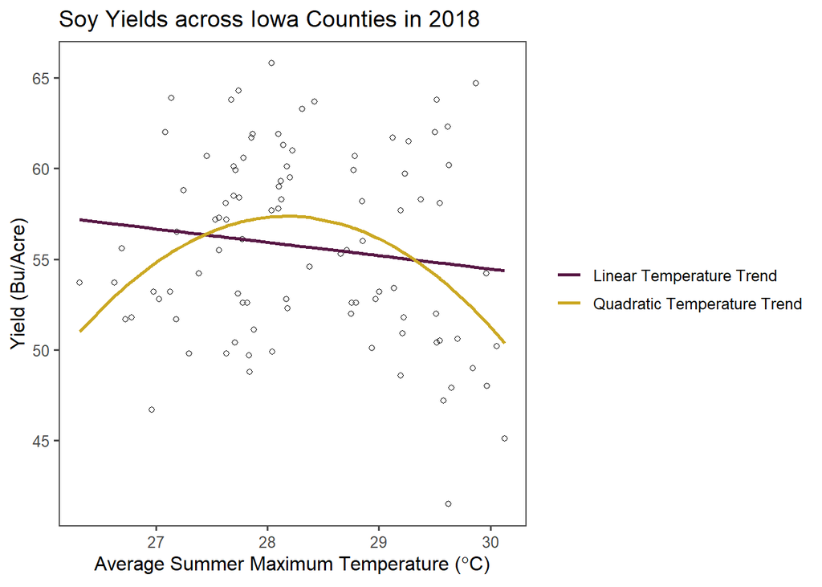

```r
#Combined plot of linear and quadratic temperature models

ggplot(aes(x = meantmax, y = yield), data = soytmax2018) +
  geom_point(shape = 1) +
  geom_line(mapping = aes(x=meantmax, y=fitted_l, col="Linear Temperature Trend"), size=1)+
  geom_line(mapping = aes(x=meantmax, y=fitted_q, col="Quadratic Temperature Trend"),size=1)+
  labs(colour = NULL) +
  theme_few() +
  scale_color_manual(values=c("#581845","#CBA823"))+
  labs(x = expression("Average Summer Maximum Temperature ("*degree*C*")"), y = "Yield (Bu/Acre)", title = "Soy Yields across Iowa Counties in 2018")
```

### Bonus: Find a package to make a county map of Iowa displaying some sort of information about yields or weather. Interpret your map.

```r
#Load packages to create county map of Iowa

library(USAboundaries)
library(USAboundariesData)
library(mapview)

#Select needed columns

counties <- us_counties(states = 'iowa') %>%
  dplyr::select(name, geometry)

#Adjust capitalization of county names

counties$name <- toupper(counties$name)
```

```r
#Simplify data by only mapping yield data from one year

cornyield_2017 <- corn_yields %>%
  filter(year==2017) %>%
  dplyr::select(county_name, yield, countyfp)

#Combine yield and spatial county data

co_yields <- merge(counties, cornyield_2017, by.x = "name", by.y = "county_name", all.x=TRUE)

#Map yield by county

mapview(co_yields, zcol= 'yield', layer.name="2017 Corn Yield - Bu per Acre")
```

[interactive chart not shown]

Viewing the map of 2017 corn yields across Iowa counties (especially in tandem with the maps below), there appears to be a spatial pattern where corn yields are generally lowest in southern Iowa counties. Furthermore, specifically for the 2017 year, there appears to be higher corn yields in the eastern portion of the state versus the western side.

### Bonus #2: Challenge question - map trends in corn yields by county across Iowa. Interpret your map.

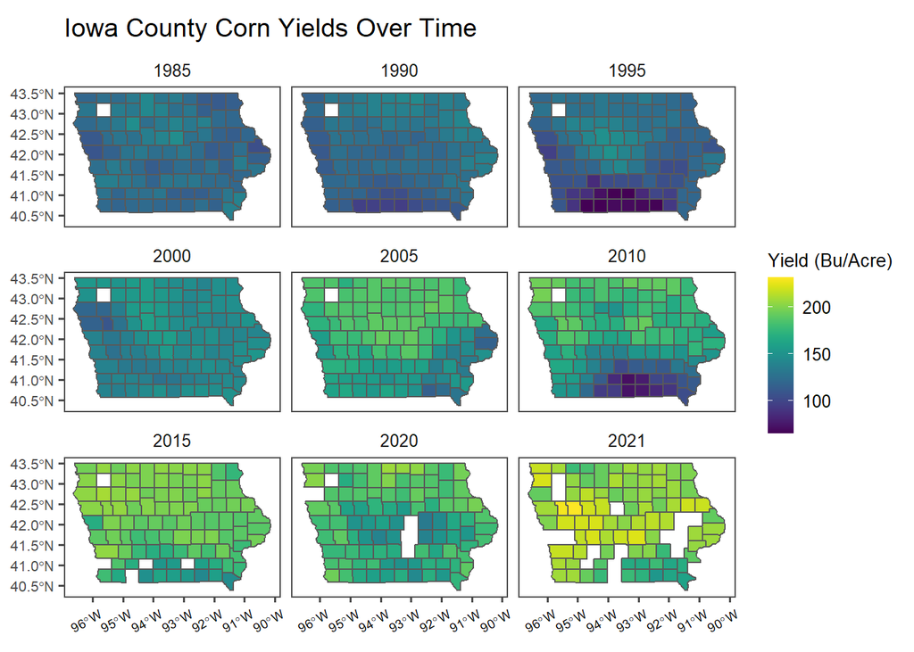

```r
#Create data frame with corn yield from last 9 years

cornyield_time <- corn_yields %>%
  filter (year %in% c(1985,1990,1995,2000,2005,2010,2015,2020,2021)) %>%
   dplyr::select(year, county_name, yield, countyfp)

#Join to counties spatial data

co_yields_time <- merge(counties, cornyield_time, by.x="name", by.y="county_name", all.x=TRUE)


#Use facet wrap by year to show corn yield over the last 9 years

ggplot(na.omit(co_yields_time), aes(fill = yield)) + geom_sf() +
  scale_fill_viridis() + theme_few() +
  facet_wrap( ~ year, nrow = 3) +
  theme(axis.text.x = element_text(
    color = "black",
    size = 7,
    angle = 30,
    vjust = .8,
    hjust = .8
  )) +
  theme(axis.text.y = element_text(size = 8))+
  labs(title="Iowa County Corn Yields Over Time", fill="Yield (Bu/Acre)")+
  theme(legend.position = "right",
        legend.key.width = unit(5, "mm"), legend.title=element_text(size=10))
```

The map(s) above shows corn yields across Iowa counties in 5 year intervals, in addition to the two most recent years with yield data. Broadly, this map is supportive of earlier findings from our analyses, where corn yields have generally increased with time. Spatially, the map indicates that south-central Iowa counties produce lower corn yields consistently over time, in comparison to other counties.